# Mine the Gap: Micro-Targeting Patients for Care Coordination & Social Support Services

#### Ceslee Montgomery

#### July 9, 2015

## Motivation

[figure not shown]

## Problem

- What can interesting and non-obvious insights can we learn about the patients we serve?
- From a patient's perspective, where are the gaps in care?
- Ultimately, where are the opportunities for improved system management for most at-risk enrollees?

## Goal

- Segment Population
- Segment Profile Analysis
- Segment Feature Analysis

## The Data

### 2013 HOS Survey

- Medicare Population Survey
  - a broad assessment of physical and mental health functioning of Medicare beneficiaries
  - consists of several surveys (VR12, HEDIS Quality of Care, etc)
  - 83 fields

### The Final Dataset

- 10K Record sample from 303K total
- broke this into 4 domains
  - Demographic Profile
  - Disease Profile
  - Wellness Profile
  - Needs Profile

# Model Selection

- Micro-Segmenting Populations is an Unsupervised Problem: so, Clustering.
- Why Clustering?
  - Well-studied machine learning task: grouping objects so that objects in groups are more similar than those in others. Then, generalize from groups.
  - Used in marketing to personalize marketing, develop new services product offerings.

##### As you recall this is how it works:

1. Choose k-initial centroids
2. For each point: (a) distance to centroid, (b) assign point to nearest centroid
3. Recalculate centroid positions
4. Repeat steps 2-3 until stopping criteria are met.

##### This is how we measure success:

**Sum of Squared Errors Definition:**

$$ SSE = \displaystyle\sum_{i=1}^{K}\sum_{x \in C_i} d(x, c_i)^2 $$

**Silhouette Coefficient Definition:**

$$ SC_{total} = 1/k \displaystyle\sum_{1}^{k}SC(C_{i}) $$

## Build Model

##### Overview:

- Train on wellness + needs data, investigate demographic profiles, and evaluate features importance.

##### Plan:

- Choose K
- Fit data to optimal K
- Proceed with analyzing our cohorts.

Now implementation...

```python
km_X = km_X.sample(n=10000, random_state=1)
```

```python
k_range = range(2,10)
```

Here we'll run "k_range" models with k clusters.

```python
# %%timeit

SSEs = []
Sil_coefs = []

for k in k_range:
    #instantiate KMeans object
    km = KMeans(n_clusters=k, random_state=1)
    #fit model to training data
    km.fit(km_X)
    labels = km.labels_
    #store SC & SSE scores for each k run
    Sil_coefs.append(metrics.silhouette_score(km_X, labels, metric='euclidean'))
    SSEs.append(get_SSE(km_X, labels))
```

## Evaluate Model

Let's plot the SSE and SC to see where our optimum k lies.

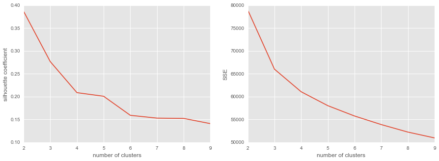

```python
fig, (ax1, ax2) = plt.subplots(1,2, figsize=(15,5), sharex=True)
ax1.plot(k_range, Sil_coefs)
ax1.set_xlabel('number of clusters')
ax1.set_ylabel('silhouette coefficient')

# plot here on ax2
ax2.plot(k_range, SSEs)
ax2.set_xlabel('number of clusters')
ax2.set_ylabel('SSE');
```

What we can do is visualize a PCA-reduced 2-dim plot of our clustering job to see if that will help us make a final call.

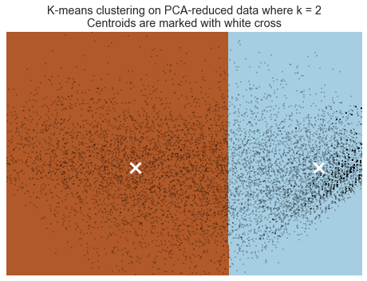

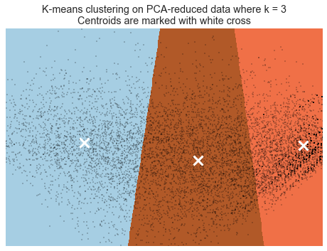

```python
# Visualize the results on PCA-reduced data
from sklearn.decomposition import PCA

reduced_data = PCA(n_components=2).fit_transform(km_X)

ax1 = show_kmeans_plot(1, 2, reduced_data)
ax2 = show_kmeans_plot(2, 3, reduced_data)
```

## Segment Profile Analysis

### Demographic Differences

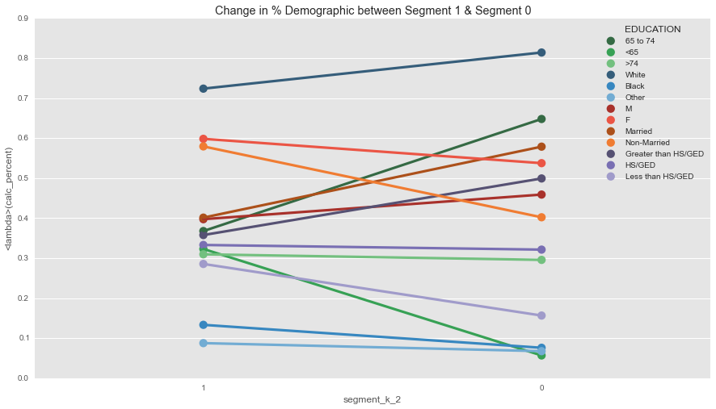

```python
fig = plt.subplots(1,1, sharey=True, figsize=(15,8))

sns.pointplot(estimator=sum_function, x='segment_k_2', y='calc_percent', hue='AGE', data=profile_seg, palette="Greens_d").set_title('Change in % Demographic between Segment 1 & Segment 0');
sns.pointplot(estimator=sum_function, x='segment_k_2', y='calc_percent', hue='RACE', data=profile_seg, palette="Blues_d");
sns.pointplot(estimator=sum_function, x='segment_k_2', y='calc_percent', hue='GENDER', data=profile_seg, palette="Reds_d");
sns.pointplot(estimator=sum_function, x='segment_k_2', y='calc_percent', hue='MARITALSTAT', data=profile_seg, palette="Oranges_d");
sns.pointplot(estimator=sum_function, x='segment_k_2', y='calc_percent', hue='EDUCATION', data=profile_seg, palette="Purples_d");
```

What's nice about this plot is it gives us two pieces of information: % Demographic for each segment and the % change between segment 1 and segment 2.

```python
#for each column of interest
demog_cols = list(profile_seg.columns[:5])
draw_table(demog_cols)
```

| Demographic Characteristics | X^2 (p) | Segment 1(%) | Segment 0 (%) | Odds Ratio |
| --- | --- | --- | --- | --- |
| AGE | 1390.2 (1.32E-302) |  |  |  |
| 65 to 74 |  | 36.8 | 64.8 | 0.3 |
| <65 |  | 32.3 | 5.7 | 7.9 |
| >74 |  | 31.0 | 29.6 | 1.1 |
| RACE | 118.1 (2.27E-26) |  |  |  |
| Black |  | 13.3 | 7.6 | 1.9 |
| Other |  | 8.8 | 6.7 | 1.3 |
| White |  | 72.4 | 81.4 | 0.6 |
| GENDER | 36.8 (1.29E-09) |  |  |  |
| F |  | 59.8 | 53.7 | 1.3 |
| M |  | 39.7 | 45.9 | 0.8 |
| MARITALSTAT | 309.9 (2.35E-69) |  |  |  |
| Married |  | 40.1 | 57.9 | 0.5 |
| Non-Married |  | 57.9 | 40.2 | 2.0 |
| EDUCATION | 303.2 (1.46E-66) |  |  |  |
| Greater than HS/GED |  | 35.8 | 49.9 | 0.6 |
| HS/GED |  | 33.3 | 32.1 | 1.1 |
| Less than HS/GED |  | 28.5 | 15.6 | 2.2 |

```python
#Explore why 8 times more <65
profile_seg.pivot_table(['DEPRESSION', 'MCC', 'SMOKER'], index='AGE')
```

| AGE | DEPRESSION | MCC | SMOKER |
| --- | --- | --- | --- |
| 65 to 74 | 0.193603 | 2.811643 | 0.122182 |
| <65 | 0.596725 | 3.669675 | 0.304321 |
| >74 | 0.168957 | 3.333886 | 0.049883 |

### Regional Differences

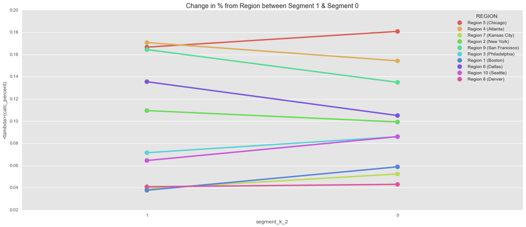

```python
fig_region = plt.subplots(1,1, figsize=(20,8))
sns.pointplot(estimator=sum_function, x='segment_k_2', y='calc_percent', hue='REGION', data=profile_seg, palette="hls").set_title('Change in % from Region between Segment 1 & Segment 0');
```

```python
#for each column of interest
region_cols = ['REGION']
draw_table(region_cols)
```

| Demographic Characteristics | X^2 (p) | Segment 1(%) | Segment 0 (%) | Odds Ratio |
| --- | --- | --- | --- | --- |
| REGION | 2110.7 (0.00E+00) |  |  |  |
| Region 1 (Boston) |  | 4.1 | 6.0 | 0.7 |
| Region 10 (Seattle) |  | 6.8 | 8.4 | 0.8 |
| Region 2 (New York) |  | 11.1 | 9.4 | 1.2 |
| Region 3 (Philadelphia) |  | 7.3 | 8.7 | 0.8 |
| Region 4 (Atlanta) |  | 16.9 | 15.2 | 1.1 |
| Region 5 (Chicago) |  | 16.1 | 18.6 | 0.8 |
| Region 6 (Dallas) |  | 14.7 | 10.6 | 1.4 |
| Region 7 (Kansas City) |  | 3.9 | 5.3 | 0.7 |
| Region 8 (Denver) |  | 3.9 | 4.4 | 0.9 |
| Region 9 (San Francisco) |  | 15.2 | 13.4 | 1.2 |

There doesn't seem to be major regional variance. At most there appears to be 4% difference among a region between the segments.

### Chronic Conditions

```
	 	 # of Chronic Conditions by Segment
```

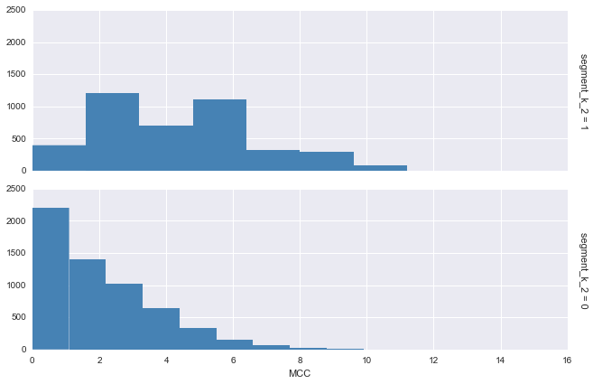

```python
print '\t \t # of Chronic Conditions by Segment'
g = sns.FacetGrid(profile_seg, aspect=3, row='segment_k_2', margin_titles=True);
g.map(plt.hist, 'MCC', color="steelblue", lw=0);
```

### Disease Indicators

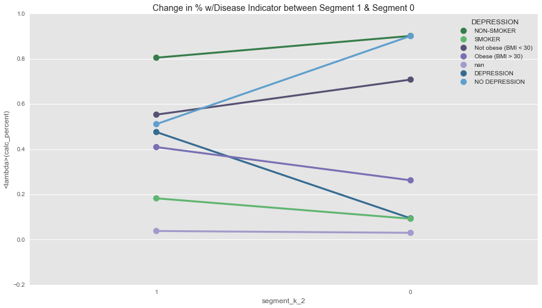

```python
fig2 = plt.subplots(1,1, sharey=True, figsize=(15,8))

profile_seg.replace({
        'SMOKER':{0:'NON-SMOKER', 1:'SMOKER'},
        'DEPRESSION':{0:'NO DEPRESSION',1:'DEPRESSION'},
        'AT-RISK':{False:'NOT AT-RISK', True:'AT-RISK'},
        'CC-NEED':{False:'NO CC-NEEDED', True:'CC-NEEDED'}
    }, inplace=True)

profile_seg['OBESE'] = profile_seg['OBESE'].map(lambda x: str(x).decode('utf-8').strip())

sns.pointplot(estimator=sum_function, x='segment_k_2', y='calc_percent', hue='SMOKER', data=profile_seg, palette="Greens_d").set_title('Change in % w/Disease Indicator between Segment 1 & Segment 0');
sns.pointplot(estimator=sum_function, x='segment_k_2', y='calc_percent', hue='OBESE', data=profile_seg, palette="Purples_d");
sns.pointplot(estimator=sum_function, x='segment_k_2', y='calc_percent', hue='DEPRESSION', data=profile_seg, palette="Blues_d");
```

```python
#@CEslee: depression table
#for each column of interest
disease_indicators_cols = list(profile_seg.columns[7:10])
draw_table(disease_indicators_cols)
```

| Demographic Characteristics | X^2 (p) | Segment 1(%) | Segment 0 (%) | Odds Ratio |
| --- | --- | --- | --- | --- |
| OBESE | 256.9 (1.62E-56) |  |  |  |
| Not obese (BMI < 30) |  | 55.3 | 70.8 | 0.5 |
| Obese (BMI > 30) |  | 40.9 | 26.2 | 1.9 |
| nan |  | 3.8 | 3.0 | 1.3 |
| SMOKER | 178.2 (1.22E-40) |  |  |  |
| NON-SMOKER |  | 80.5 | 90.1 | 0.5 |
| SMOKER |  | 18.3 | 9.2 | 2.2 |
| DEPRESSION | 1903.3 (0.00E+00) |  |  |  |
| DEPRESSION |  | 47.6 | 9.4 | 8.7 |
| NO DEPRESSION |  | 51.1 | 90.1 | 0.1 |

### And Finally..."Gold Standard" Targets

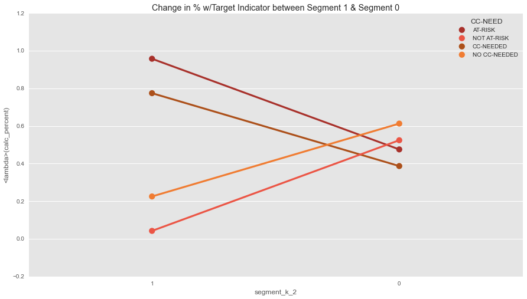

```python
fig3 = plt.subplots(1,1, sharey=True, figsize=(15,8))
sns.pointplot(estimator=sum_function, x='segment_k_2', y='calc_percent', hue='AT-RISK', data=profile_seg, palette="Reds_d").set_title('Change in % w/Target Indicator between Segment 1 & Segment 0');
sns.pointplot(estimator=sum_function, x='segment_k_2', y='calc_percent', hue='CC-NEED', data=profile_seg, palette="Oranges_d");
```

There's no doubt a latent correlation here between disease indicators and having higher gaps in your wellness profile and needs profile. We'll explore those next.

```python
#for each column of interest
targets_cols = list(profile_seg.columns[11:13])
draw_table(targets_cols)
```

| Demographic Characteristics | X^2 (p) | Segment 1(%) | Segment 0 (%) | Odds Ratio |
| --- | --- | --- | --- | --- |
| AT-RISK | 51497.8 (0.00E+00) |  |  |  |
| AT-RISK |  | 95.7 | 48.6 | 23.4 |
| NOT AT-RISK |  | 4.3 | 51.4 | 0.0 |
| CC-NEED | 29717.6 (0.00E+00) |  |  |  |
| CC-NEEDED |  | 77.2 | 39.2 | 5.3 |
| NO CC-NEEDED |  | 22.8 | 60.8 | 0.2 |

Whoa! Segment 1 is 23 times more likely to be At-Risk. I think we have a name for our first segment now.

## Segment Factor Analysis

### Needs Analysis

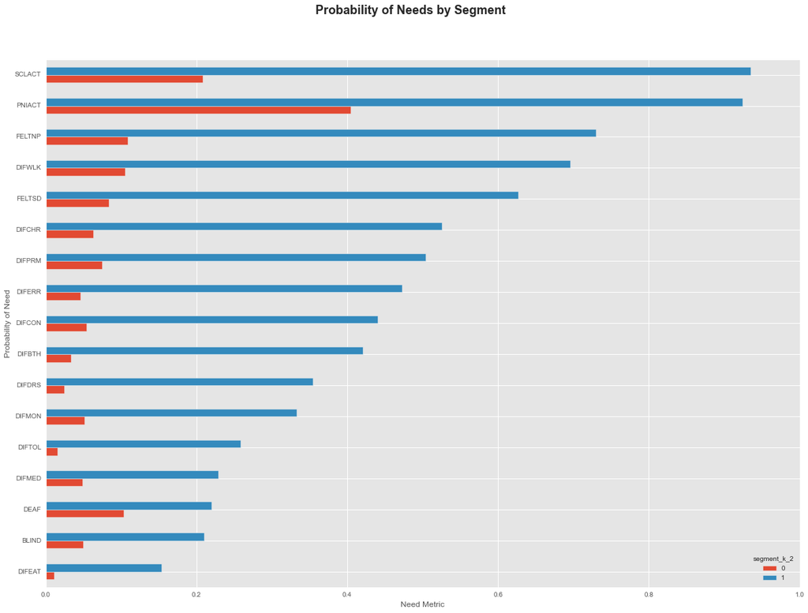

```python
#prob of needs in sort order vertical
fig = plt.figure()
fig.suptitle('Probability of Needs by Segment', fontsize=18, fontweight='bold')

ax = fig.add_subplot(111)
ax.set_xlabel('Need Metric')
ax.set_ylabel('Probability of Need')

needs_cols = list(needs_wellness_seg.columns[0:17])  + ['segment_k_2']
needs_seg = needs_wellness_seg[needs_cols]
chart = pd.pivot_table(needs_seg, index='segment_k_2').transpose().sort(columns=[1]).plot(kind='barh', ax=ax, figsize=(20,14))
```

```python
#test model
target_predicted = lr.predict(features_test)

from sklearn.metrics import accuracy_score

print 'Logistic Reg Model: {:.3f}'.format(accuracy_score(target_test, target_predicted))

print 'Baseline Model: {:.3f}'.format(target.mean())
```

```
Logistic Reg Model: 0.850
Baseline Model: 0.411
```

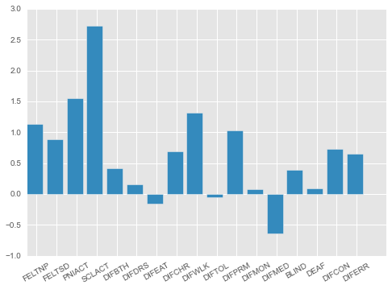

```python
feature_names = needs_seg.columns[:-1].values
feature_names
x = np.arange(len(feature_names))
plt.bar(x, lr.coef_.ravel())
_ = plt.xticks(x + 0.5, feature_names, rotation=30)
```

```python
pd.DataFrame({'Coefficient':lr.coef_.ravel()}, index=feature_names).sort('Coefficient', ascending=False)
```

|  | Coefficient |
| --- | --- |
| SCLACT | 2.724982 |
| PNIACT | 1.545890 |
| DIFWLK | 1.322018 |
| FELTNP | 1.135560 |
| DIFPRM | 1.034514 |
| FELTSD | 0.893270 |
| DIFCON | 0.736658 |
| DIFCHR | 0.689553 |
| DIFERR | 0.648140 |
| DIFBTH | 0.418644 |
| BLIND | 0.387963 |
| DIFDRS | 0.161835 |
| DEAF | 0.096940 |
| DIFMON | 0.078090 |
| DIFTOL | -0.051379 |
| DIFEAT | -0.149342 |
| DIFMED | -0.642077 |

### Wellness Gaps

```python
%%html
<!-- inspired by http://nbremer.blogspot.nl/2013/09/making-d3-radar-chart-look-bit-better.html -->
<head>
    <meta http-equiv="Content-Type" content="text/html;charset=utf-8"/>
    <title>Radar chart</title>
    <script src="http://d3js.org/d3.v3.min.js"></script>
    <script src="radar-chart/RadarChart.js"></script>
    <style>
        body {
            overflow: hidden;
            margin: 0;
            font-size: 14px;
            font-family: "Helvetica Neue", Helvetica;
        }
        #chart {
            position: floating;
        }
    </style>
</head>
<body>
    <div id="body">
        <div id="chart"></div>
    </div>
    <script src="radar-chart/script.js"></script>
</body>
```

```python
#test model
target_predicted = lr.predict(features_test)

from sklearn.metrics import accuracy_score

print 'Logistic Reg Model: {:.3f}'.format(accuracy_score(target_test, target_predicted))

print 'Baseline Model: {:.3f}'.format(target.mean())
```

```
Logistic Reg Model: 0.950
Baseline Model: 0.411
```

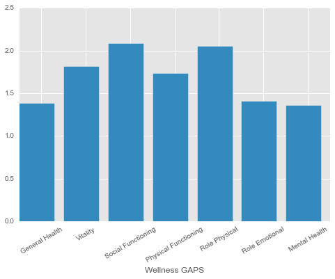

```python
feature_names = wellness_seg.columns[:-1].values
x = np.arange(len(feature_names))
plt.bar(x, lr.coef_.ravel())
_ = plt.xticks(x + 0.5, feature_names, rotation=30)

plt.xlabel('Wellness GAPS')
```

```python
pd.DataFrame({'Coefficient':lr.coef_.ravel()}, index=feature_names).sort('Coefficient', ascending=False)
```

|  | Coefficient |
| --- | --- |
| Social Functioning | 2.086957 |
| Role Physical | 2.053376 |
| Vitality | 1.815124 |
| Physical Functioning | 1.737777 |
| Role Emotional | 1.408242 |
| General Health | 1.381125 |
| Mental Health | 1.357591 |

## Final Model Evaluation

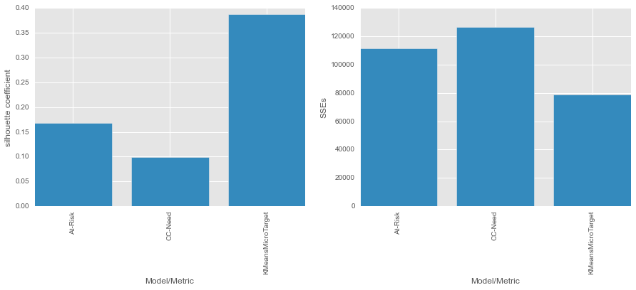

```python
#Plot AtRisk, CC-Need, segment_k_3 against health factors to evaluate
#precision for the three? how many true, true for AtR-seg, CC-seg

#1. SC and SSE on other class labels
X = km_X

#get index from X, retrieve AtR from Profile
AtR_labels = profile.loc[(km_X.index), 'AT-RISK'].values
CC_Need_labels = profile.loc[(km_X.index), 'CC-NEED'].values

def get_scores(X, labels):
    #store SC & SSE scores for each model
    Sil_coef = metrics.silhouette_score(X, labels, metric='euclidean')
    SSE = get_SSE(X, labels)
    return SSE, Sil_coef

AtR_SSE, AtR_Sil_coef = get_scores(X, AtR_labels)
CC_Need_SSE, CC_Need_Sil_coef = get_scores(X, CC_Need_labels)

model_labels = ['At-Risk', 'CC-Need', 'KMeansMicroTarget']
model_Sil_Coefs = [AtR_Sil_coef, CC_Need_Sil_coef, Sil_coefs[0]]
model_SSEs = [AtR_SSE, CC_Need_SSE, SSEs[0]]


fig_compare, (ax1, ax2) = plt.subplots(1,2, figsize=(15,5), sharex=True)

width=0.8
ax1.bar(x1, model_Sil_Coefs, width=width)
ax1.set_xticks(x1 + width/2)
ax1.set_xticklabels(model_labels, rotation=90)
ax1.set_xlabel('Model/Metric')
ax1.set_ylabel('silhouette coefficient')

# # plot here on ax2
ax2.bar(x1, model_SSEs, width=width)
ax2.set_xticks(x1 + width/2)
ax2.set_xticklabels(model_labels, rotation=90)
ax2.set_xlabel('Model/Metric')
ax2.set_ylabel('SSEs')
```

## Wrap-Up

##### Segment 1 == 'Sick and Shut In'

- Greater relative % of <65 year olds, non-married individuals, and slighlty more women
- Pain in daily activities, difficulty walking, and trouble integrating with their social circle because of their poorer health, this is also often accompanied by depression.

##### Segment 0 == 'So-So Segment'

- greater relative percentage of **65 to 74 year olds, Whites, and individuals with greater than a HS/GED
- less at-risk and probably ignored by the system. But these individuals do tend to have difficulties with difficulty using toilet without assistance and difficulty taking medication.

## Future stuff:

- Develop Personas to share insights with healthcare providers.
- Predictive Modeling to proactively target new beneficiaries.
- Learning more about why social activity is so common and thus an important feature in both segments.
- Breaking analysis down by disease types.

# Thank You!

### Special thanks to GA Teaching Team + Staff.

# Questions?

[figure not shown]